# Combine Transfermarkt data

Author

Moneyballers

Published

November 19, 2025

### Code for joining club and player data together.

This project started with the intention of using the [worldfootballR](https://jaseziv.github.io/worldfootballR/articles/load-scraped-data.html) package to scrap data from [Transfermarkt](https://www.transfermarkt.us/marktwertetop/wertvollstespieler). However, there are several limitations to this package such as time out api requests and failure to capture dynamic java tables on a web page. Luckily, kaggle already contains the data we need for this project under “[**Football Data from Transfermarkt**](https://www.kaggle.com/datasets/davidcariboo/player-scores?resource=download)**.**” The only thing needed is to merge tables and generate club level predictors to build a multilevel model to explain variation in team and player market value growth curves.

- This code can be found at https://github.com/klinares/Moneyball_FC.
- First, we compiled a table from [UEFA](https://www.uefa.com/nationalassociations/uefarankings/tenyears/?year=2025) containing rankings of European teams based on their 10 year coefficient ranking. We select the first 21 teams to only focus on the top teams in Western Europe.
  - The UEFA club coefficient is a ranking system that measures the performance of clubs in UEFA competitions over the previous five seasons. Clubs earn points for wins, draws, and reaching certain stages of tournaments, and the total is used to determine seeding for future competition draws.
  - Here we print the top 21 teams by rank. Note, this table (team_urls_df.parquet) also contains transfermarkt team URLS to be used with the worldfootballR package to enrich this data if needed.

[output not shown]

We now read in data from kaggle and begin to structure in a way to be used in our multilevel models.

- The player_valuations.parquet table contains market values during a player’s season. There are 496,606 records from January 2000 through April 2025. For this reason, we will focus on data from 2013 through 2024. Market value is in euros and ranges from 0 to 200,000,000. There are 31,078 unique players representing 437 clubs around the world.
- The players.parquet table contains players’ names, birth place, DOB, height, position played for 32,601 players.
- The appearances table breaks down game information for each player in a club with over 1.706 million records. This contains information about how many yellow or red cards a player received, or goals or assists a player had during a game. It also has the duration (in minutes) a player played during a game. This information is aggregated by player_by_year. We can also use this information to aggregate at the club_by_year, for instance, centering the average number of red cards a team received during a season.
  - Seasons run from mid August through end of May. Therefore, when we aggregate data by season, we cut it from say 2022 August through 2023 May, and label it as year = 2023.
- We use these three tables to generate a players table for the clubs and years we are interested in.
  - Overall, from 2013-2024 we are left with 2,215 players.

We use the priceR package to convert euros to dollars, and take the yearly average from 2013-2024. Following the exchange rate conversion, we have to adjust for inflation. We use the same package and for each row US nominal dollar (values of the dollar for the specific year) we convert to real dollars (value of the dollar in a constant year) in our case to the most recent year of 2024. The below code chunk makes request to the exchange API and is a long process. The below code chunk makes request to the exchange API and is a long process.

```r
yearly_exchange_rates <- tibble(
  season_year = as.double(seq(2013, 2024)),
  year_ex_rate = c(
    1.33, 1.33, 1.11, 1.11, 1.13, 1.18, 1.12, 1.14, 1.18, 1.05, 1.08, 1.08)
)

player_df <- player_df |>
  left_join(yearly_exchange_rates) |>
  mutate(market_value_ave_usd = market_value_ave * year_ex_rate) |>
  mutate(
    # Create the new column
    usd_revenue_2024 = adjust_for_inflation(
      price = market_value_ave_usd, # The nominal dollar amount to convert
      from_date = season_year,    # The year the money was from
      country = "US",      # The country for the inflation index
      to_date = 2024       # The target year you want to convert to
    )
  )
```

```
Generating URL to request all 296 results
Retrieving inflation data for US
Generating URL to request all 65 results
```

We explore the average player’s time points and find an average of 3.24 (SD=2.88) seasons played. If we drop players with less than 2 seasons, we drop down to 1,341 players.

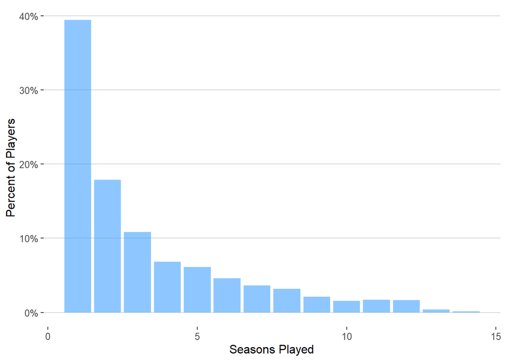

We plot the proportion of the players that have have been in C number of clubs, with almost 80% being only in 1 club during their career.

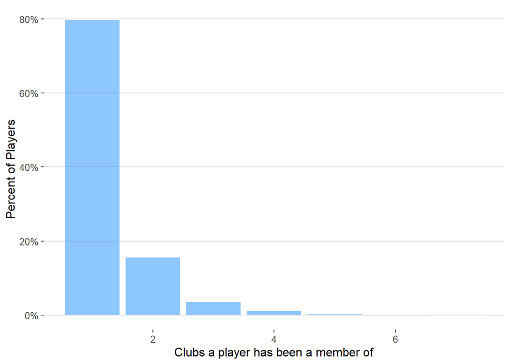

Next, we explore the average market value over time and can see a lot of variability, with some players valued very high. The first plot are in euros followed by US dollars in plot 2. The third plot is in US 2024 dollars adjusted for inflation and we can see slight changes from nominal values. The final plot is in log 2024 US dollars, which spreads lower salary values.

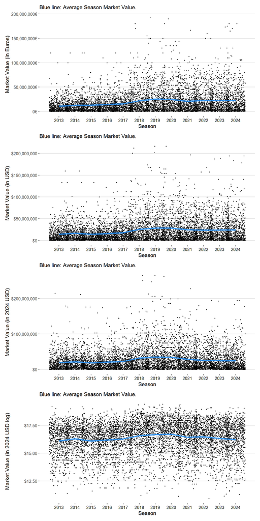

Below we plot each team’s average yearly market value in 2024 USD and on the log scale (second graph) and find that most teams have some growth but perhaps were impacted during the pandemic time frame more than other teams. We can see that on the log scale, for instance Man City, the trend line gets slightly smoothed out compared to the raw scale.

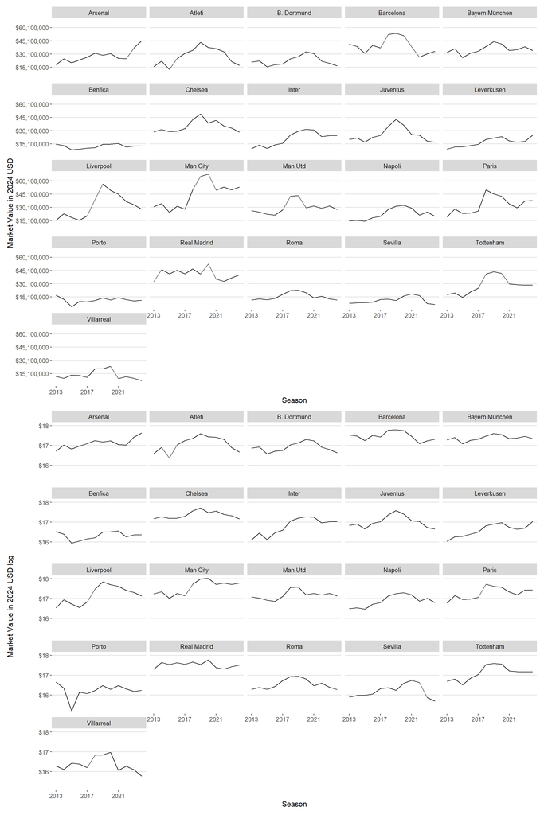

We plot the number of players per year that contribute to the total market value for each team. We observe that on average there are around 30 players per year contributing to each teams information.

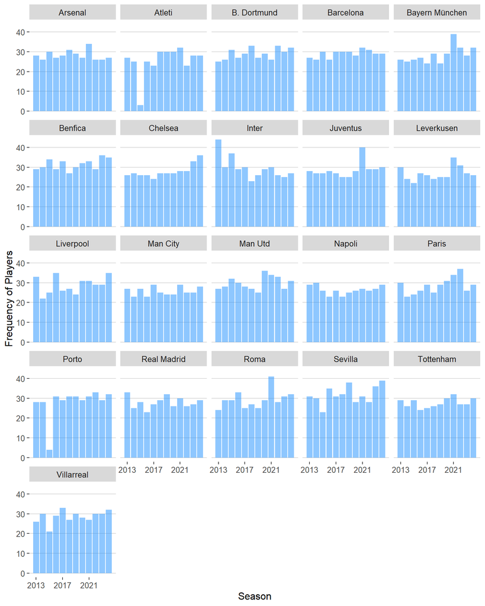

We plot age by yearly market 2024 USD value (on the log scale) for each team and observe almost an upside down u shape. The average overall age was 26.5 (SD=4.58) among these players. As you get older you are valued less in the market, same for younger players.

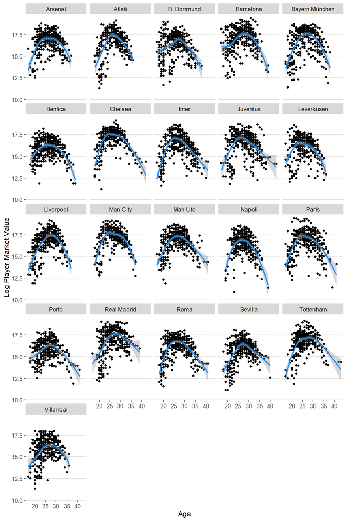

We explore the variables we will use in building the models.

- At the team (Level 3) yearly level, we compute the centered by year proportion of foreign players,.
  - We may want to enrich the teams data with predictors such as whether they won a championship for a given year, or other useful information. (i.e, sponsorship, revenue, etc.)

| club_id | season_year | foreign_players | Club | uefa_coefficient |
| --- | --- | --- | --- | --- |
| 31 | 2023 | 0.6896552 | Liverpool | 20 |
| 27 | 2018 | 0.5357143 | Bayern München | 20 |
| 31 | 2014 | 0.7272727 | Liverpool | 22 |
| 985 | 2020 | 0.5555556 | Man Utd | 26 |
| 27 | 2016 | 0.5925926 | Bayern München | 22 |
| 1049 | 2016 | 0.6896552 | Villarreal | 9 |
| 6195 | 2015 | 0.8076923 | Napoli | 13 |
| 631 | 2019 | 0.7307692 | Chelsea | 17 |
| 368 | 2021 | 0.5483871 | Sevilla | 12 |
| 11 | 2022 | 0.6538462 | Arsenal | 17 |

### There are too many countries represented in the dataframe in terms of country of birth

```r
player_df |> distinct(country_of_birth) |> count()
```

```
# A tibble: 1 × 1
      n
  <int>
1   100
```

- We can use the countrycode package to group countries into regions.

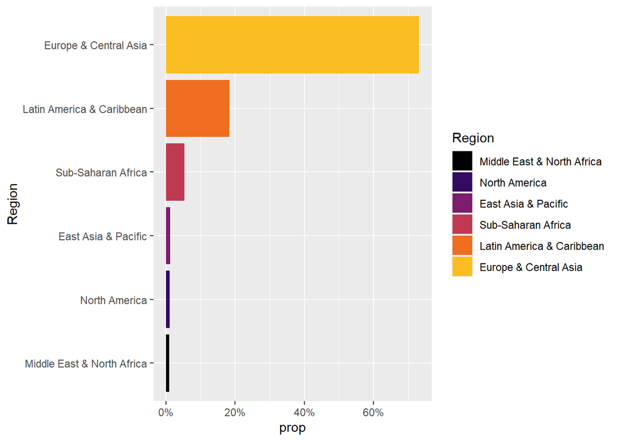

- We also want to create a binary variable that tells us if the player is a citizen of the country they play in.

```r
player_df <- player_df |>
  mutate(citizen_of_club_country = ifelse(country_of_citizenship==Country,
                                          "Yes", "No"))

player_df |>
  group_by(player_id) |>
  distinct(citizen_of_club_country) |>
  ungroup() |>
  count(citizen_of_club_country) |>
  drop_na() |>
  mutate(Percent = (n/sum(n)*100)) |>
  gt()
```

| citizen_of_club_country | n | Percent |
| --- | --- | --- |
| No | 1384 | 59.78402 |
| Yes | 931 | 40.21598 |

_________________________________________________________________________________________________________

At the player level (level 2) our predictors will include:

| name | country_of_birth | sub_position | position | height_in_cm |
| --- | --- | --- | --- | --- |
| Lionel Messi | Argentina | Right Winger | Attack | 170 |
| Cristiano Ronaldo | Portugal | Centre-Forward | Attack | 187 |

For our level 1 predictors that vary over time and by individual will include:

| name | season_year | Age | yellow_cards | red_cards | goals | assists | minutes_played |
| --- | --- | --- | --- | --- | --- | --- | --- |
| Lionel Messi | 2013 | 26 | 2 | 0 | 60 | 17 | 4070 |
| Lionel Messi | 2014 | 27 | 3 | 0 | 41 | 14 | 3743 |
| Lionel Messi | 2015 | 28 | 6 | 0 | 58 | 31 | 5061 |
| Lionel Messi | 2016 | 29 | 5 | 0 | 41 | 24 | 4229 |
| Lionel Messi | 2017 | 30 | 9 | 0 | 54 | 20 | 4452 |
| Lionel Messi | 2018 | 31 | 7 | 0 | 45 | 20 | 4468 |
| Lionel Messi | 2019 | 32 | 3 | 0 | 51 | 22 | 4024 |
| Lionel Messi | 2020 | 33 | 7 | 0 | 30 | 26 | 3631 |
| Lionel Messi | 2021 | 34 | 6 | 1 | 39 | 15 | 4373 |
| Lionel Messi | 2022 | 35 | 1 | 0 | 12 | 15 | 2872 |
| Lionel Messi | 2023 | 36 | 0 | 0 | 20 | 20 | 3457 |

Our predictor, market value varies across player and time.

| name | season_year | market_value_ave |
| --- | --- | --- |
| Lionel Messi | 2013 | 120000000 |
| Lionel Messi | 2014 | 120000000 |
| Lionel Messi | 2015 | 120000000 |
| Lionel Messi | 2016 | 120000000 |
| Lionel Messi | 2017 | 120000000 |
| Lionel Messi | 2018 | 180000000 |
| Lionel Messi | 2019 | 155000000 |
| Lionel Messi | 2020 | 126000000 |
| Lionel Messi | 2021 | 86666667 |
| Lionel Messi | 2022 | 55000000 |
| Lionel Messi | 2023 | 43333333 |

This is the proposed modeling framework so that we may model individual player growth trajectories to see how these differ across players and clubs.

- **Level 1: The Measurement Occasion.** This is the individual **season-year** for a player. Predictors at this level vary over time (e.g., a player’s age, goals, and assists change each season).
- **Level 2: The Individual.** This is the **player**. Predictors at this level are time-invariant (e.g., a player’s primary position or country of birth does not change).
- **Level 3: The Contextual Group.** This is the **club**. Players are nested within clubs, and club-level characteristics (like the proportion of foreign players or the country the club plays in) can influence player value.
  - New: We added UEFA yearly coefficients for each team.

The final dataframe is named player_df.parquet.